# visualization_1

## Advanced Scatterplot

Let’s start with name, which I can incorporate using the color aesthetic:

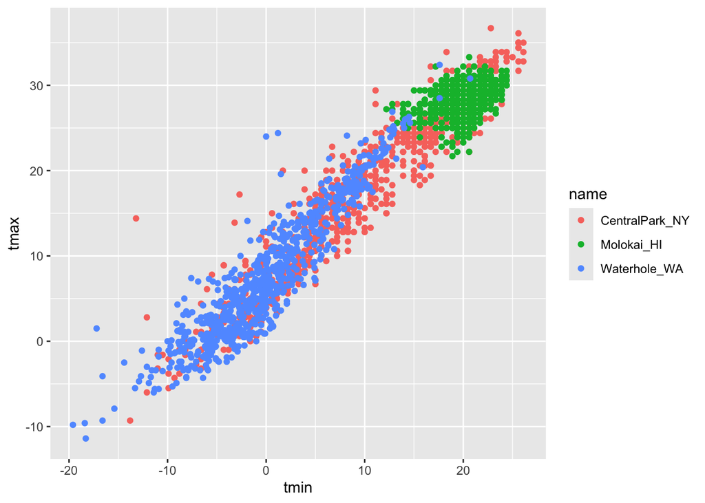

```r
ggplot(weather_df, aes(x = tmin, y = tmax)) +
  geom_point(aes(color = name))
```

Next I’ll add a smooth curve and make the data points a bit transparent.

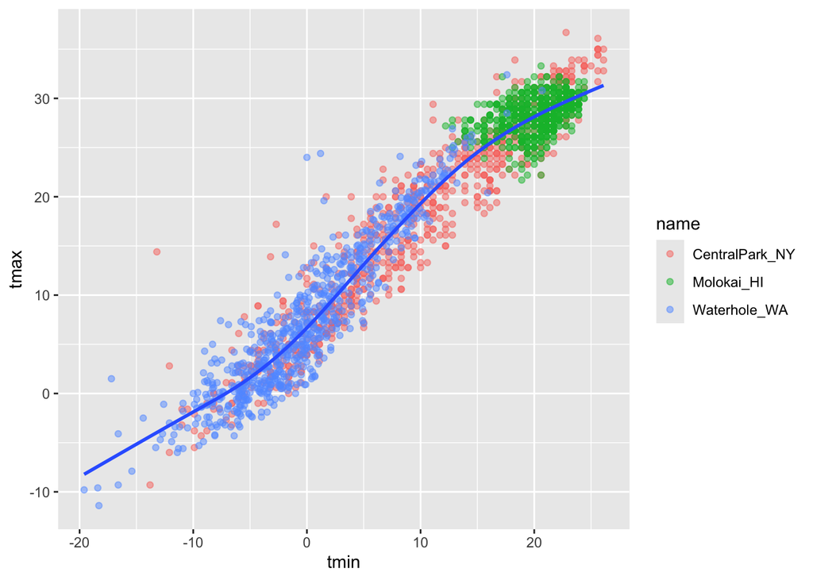

```r
ggplot(weather_df, aes(x = tmin, y = tmax)) +
  geom_point(aes(color = name), alpha = .5) +
  geom_smooth(se = FALSE)
```

The curve gives a sense of the relationship between variables, and the transparency shows where data are overlapping. I can’t help but notice, though, that the smooth curve is for all the data but the colors are only for the scatterplot. Turns out that this is due to where I defined the mappings. The X and Y mappings apply to the whole graphic, but color is currently geom-specific. Sometimes you want or need to do this, but for now I don’t like it. If I’m honest, I’m also having a hard time seeing everything on one plot, so I’m going to add facet based on name as well.

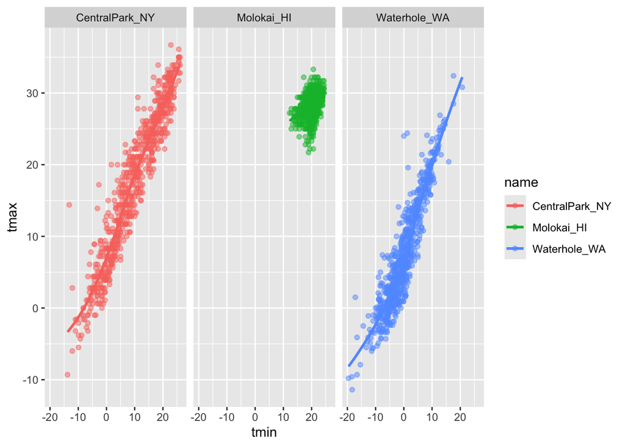

```r
ggplot(weather_df, aes(x = tmin, y = tmax, color = name)) +
  geom_point(alpha = .5) +
  geom_smooth(se = FALSE) +
  facet_grid(. ~ name) #puts on separate plots
```

Relationship between minimum and maximum temperature is now kinda boring, so I’d prefer something that shows the time of year. Also I want to learn about precipitation, so let’s do that.

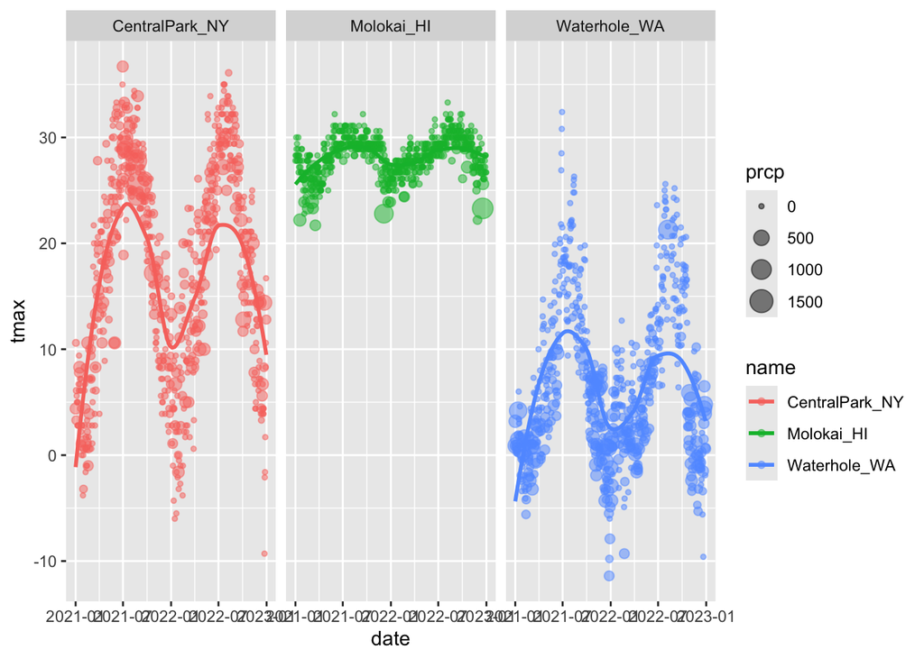

```r
ggplot(weather_df, aes(x = date, y = tmax, color = name)) +
  geom_point(aes(size = prcp), alpha = .5) +
  geom_smooth(se = FALSE) +
  facet_grid(. ~ name)
```

Learning assessment: Write a code chain that starts with weather_df; focuses only on Central Park, converts temperatures to Fahrenheit, makes a scatterplot of min vs. max temperature, and overlays a linear regression line (using options in geom_smooth()).

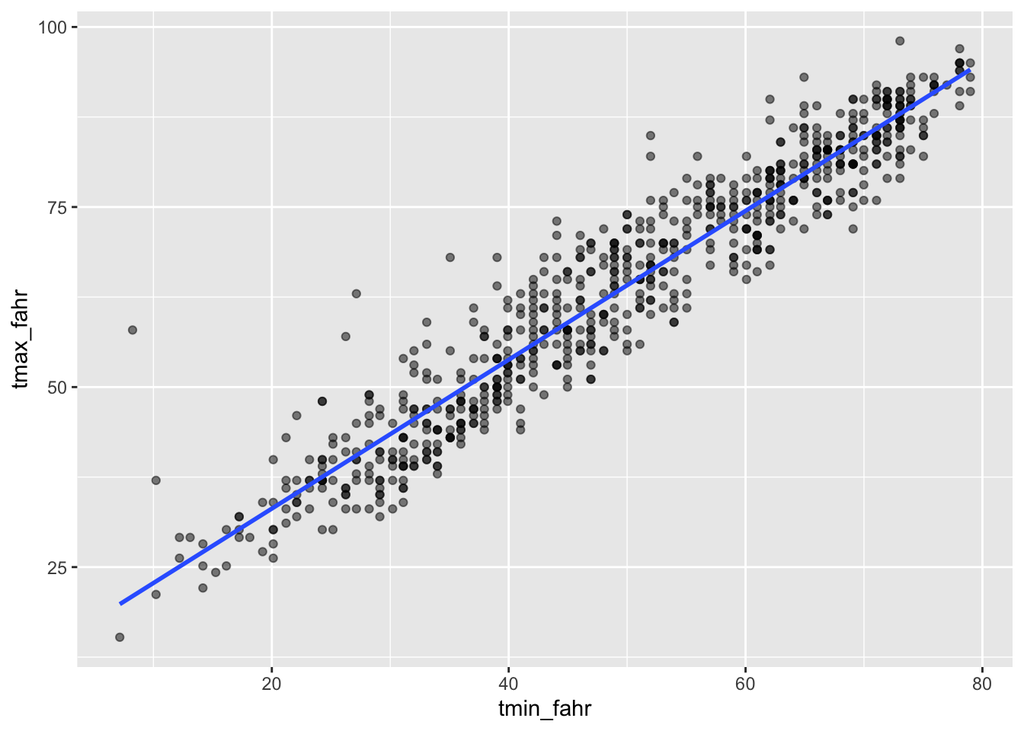

```r
weather_df |>
  filter(name == "CentralPark_NY") |> #uses piping
  mutate(
    tmax_fahr = tmax * (9 / 5) + 32,
    tmin_fahr = tmin * (9 / 5) + 32) |>
  ggplot(aes(x = tmin_fahr, y = tmax_fahr)) +
  geom_point(alpha = .5) +
  geom_smooth(method = "lm", se = FALSE)
```

# Odds and ends

There are lots of ways you can mix and match elements, depending on your goals. I don’t like the following plot as much (it doesn’t show the data and omits precipitation), but it illustrates that you have lots of freedom in determining which geoms to include and how to compare your groups. If nothing else, you should be starting to get a sense for why you create way more plots for yourself than for others.

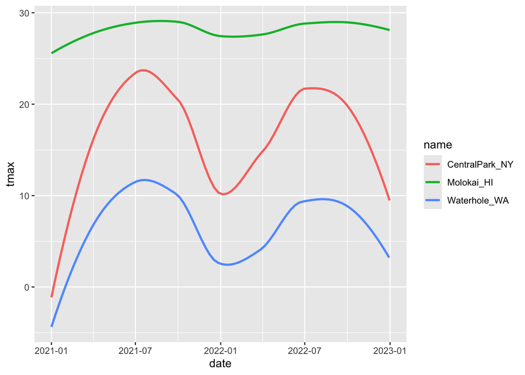

```r
ggplot(weather_df, aes(x = date, y = tmax, color = name)) + #removes geom_point
  geom_smooth(se = FALSE)
```

When you’re making a scatterplot with lots of data, there’s a limit to how much you can avoid overplotting using alpha levels and transparency. In these cases geom_hex(), geom_bin2d(), or geom_density2d() can be handy:

[figure not shown]

```r
ggplot(weather_df, aes(x = tmax, y = tmin)) +
  geom_hex()
```

Package not installed.

Learning assessment: In the preceding, we set the alpha aesthetic “by hand” instead of mapping it to a variable. This is possible for other aesthetics too. To check your understanding of this point, try to explain why the two lines below don’t produce the same result:

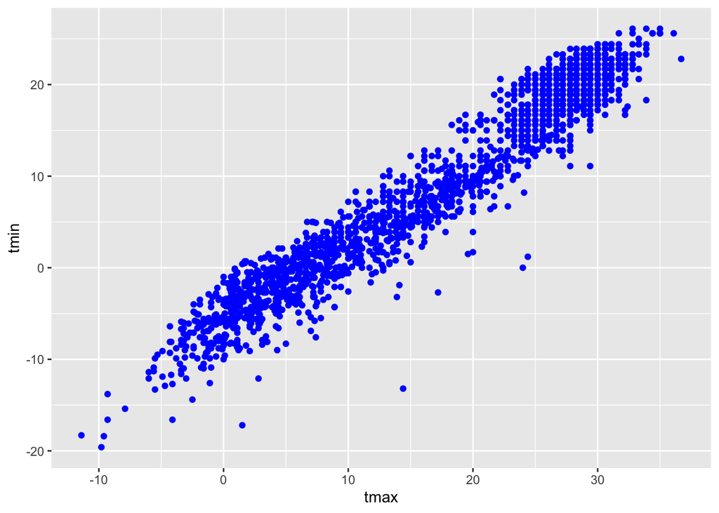

```r
ggplot(weather_df) + geom_point(aes(x = tmax, y = tmin), color = "blue")
```

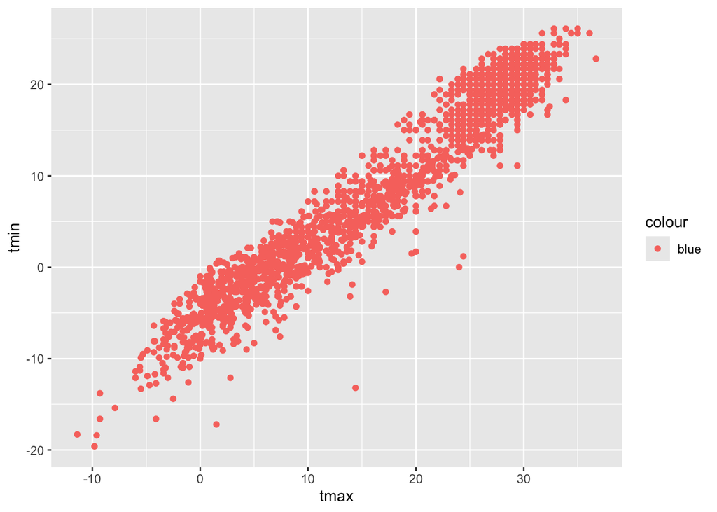

```r
ggplot(weather_df) + geom_point(aes(x = tmax, y = tmin, color = "blue"))
```

Reason why different: In the first attempt, we’re defining the color of the points by hand; in the second attempt, we’re implicitly creating a color variable that has the value blue everywhere; ggplot is then assigning colors according to this variable using the default color scheme.

## Univariate plots

Sometimes you need to carefully understand the distribution of single variables – we’ll tackle that now. This is primarily an issue of learning some new geoms and, where necessary, some new aesthetics.

First up is the histogram.

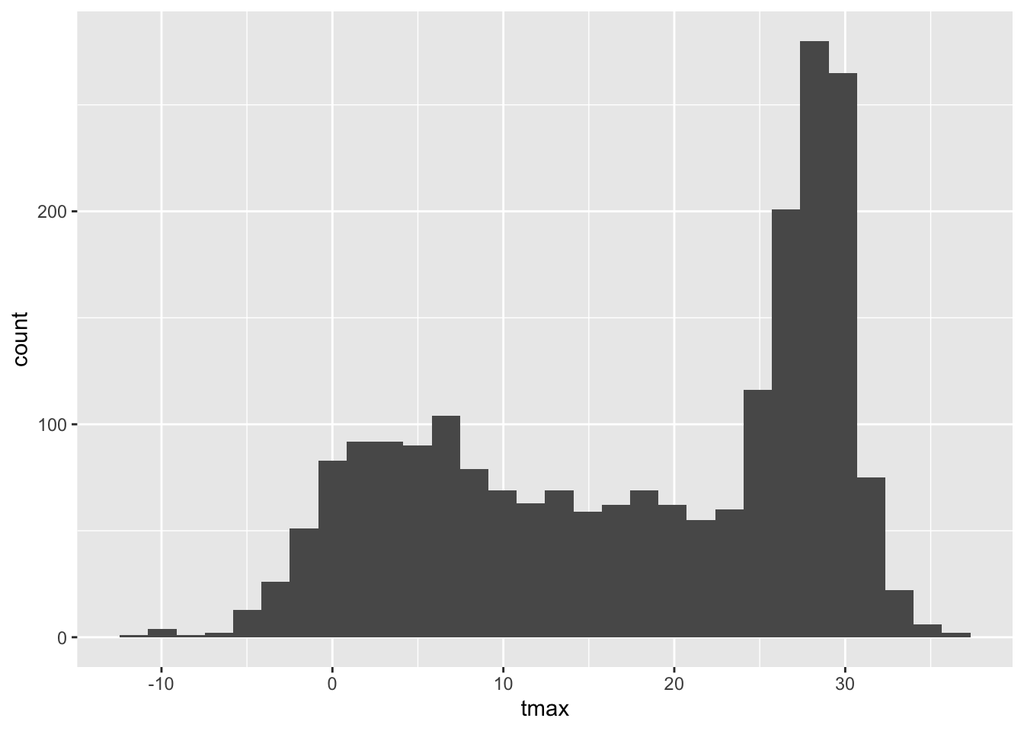

```r
ggplot(weather_df, aes(x = tmax)) +
  geom_histogram()
```

Can make them more interesting.

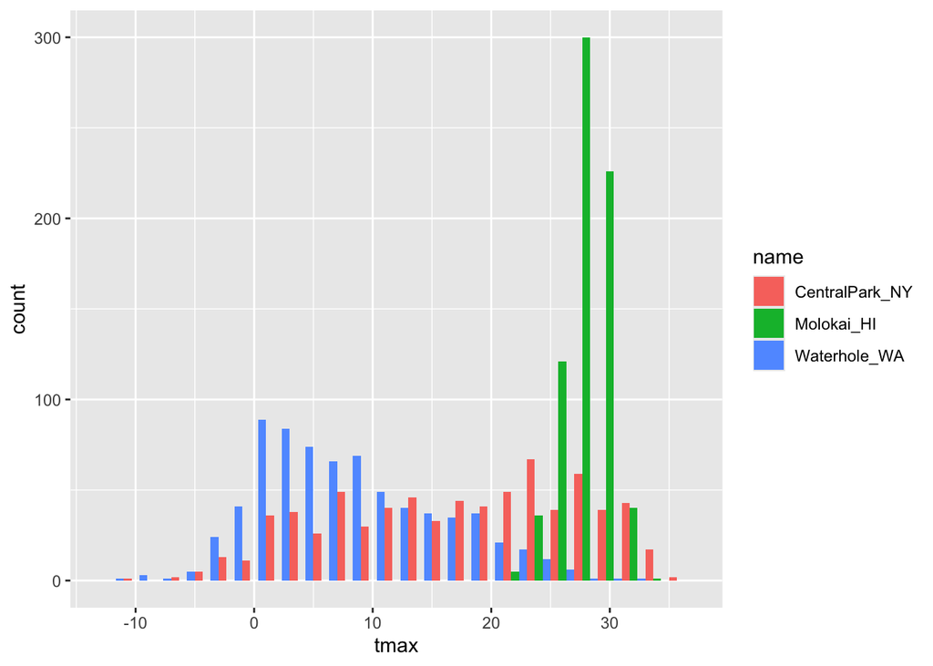

```r
ggplot(weather_df, aes(x = tmax, fill = name)) +
  geom_histogram(position = "dodge", binwidth = 2)
```

The position = “dodge” places the bars for each group side-by-side, but this gets sort of hard to understand. I often prefer density plots in place of histograms.

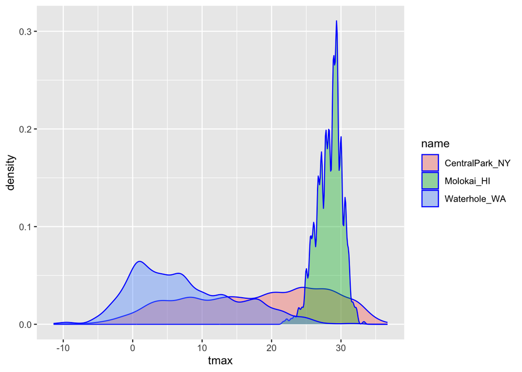

```r
ggplot(weather_df, aes(x = tmax, fill = name)) +
  geom_density(alpha = .4, adjust = .5, color = "blue")
```

The adjust parameter in density plots is similar to the binwidth parameter in histograms, and it helps to try a few values. I set the transparency level to .4 to make sure all densities appear. You should also note the distinction between fill and color aesthetics here. You could facet by name as above but would have to ask if that makes comparisons easier or harder. Lastly, adding geom_rug() to a density plot can be a helpful way to show the raw data in addition to the density.

Histograms and densities are one way of investigating univariate distributions; boxplots are another.

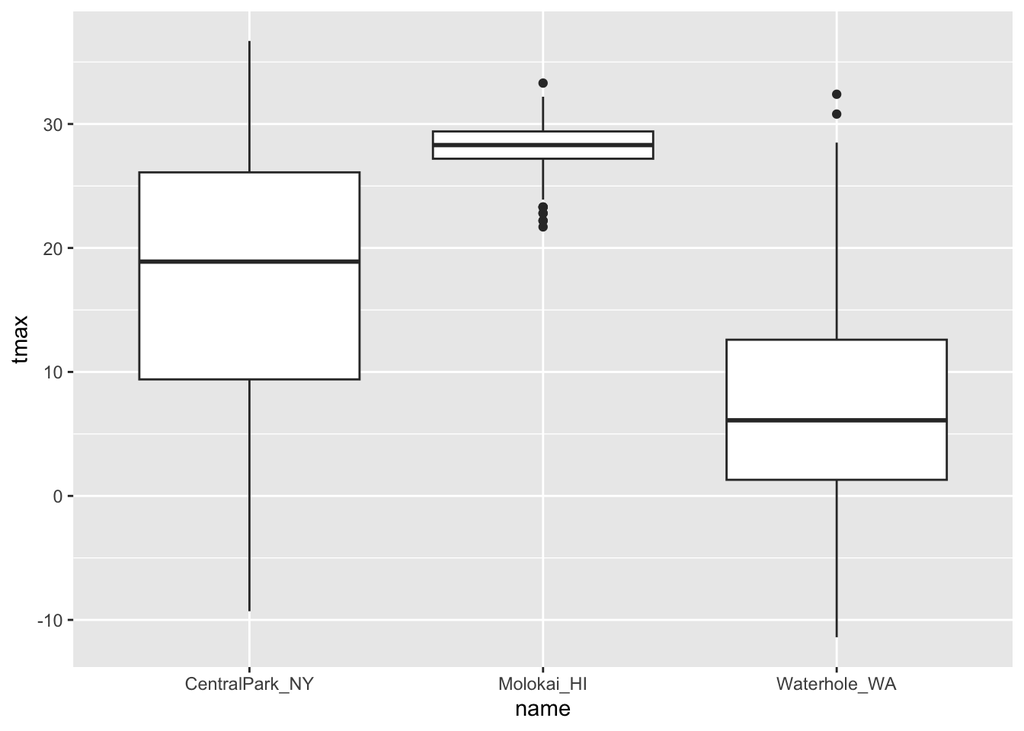

```r
ggplot(weather_df, aes(x = name, y = tmax)) +
  geom_boxplot()
```

Violin plots

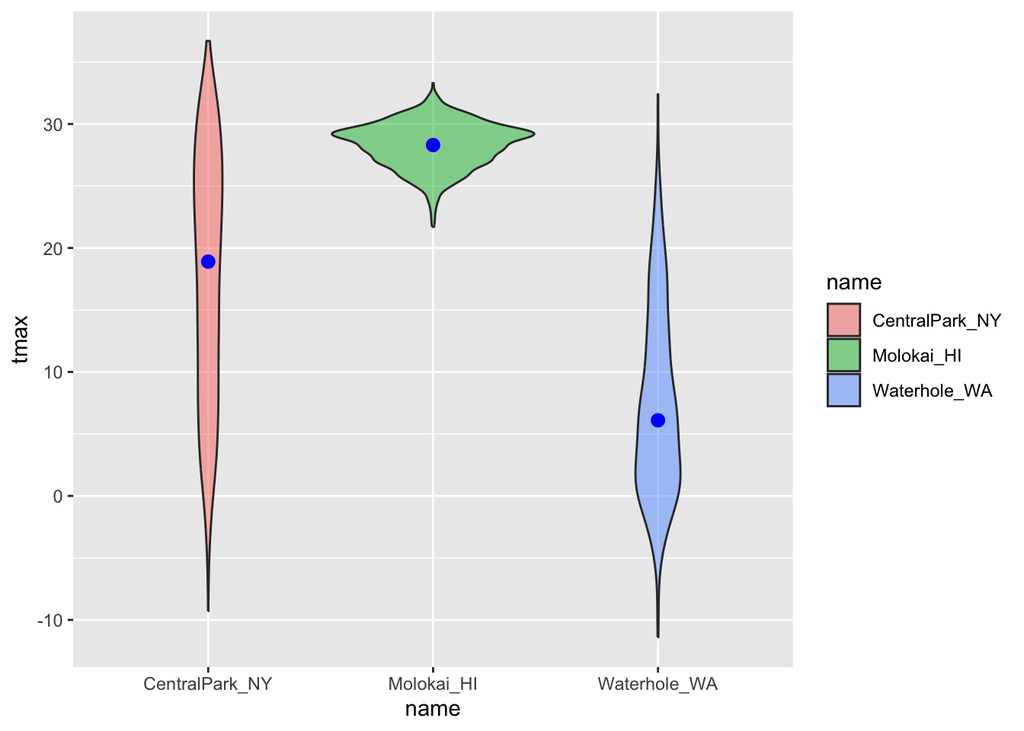

```r
ggplot(weather_df, aes(x = name, y = tmax)) +
  geom_violin(aes(fill = name), alpha = .5) +
  stat_summary(fun = "median", color = "blue")
```

Ridge plots

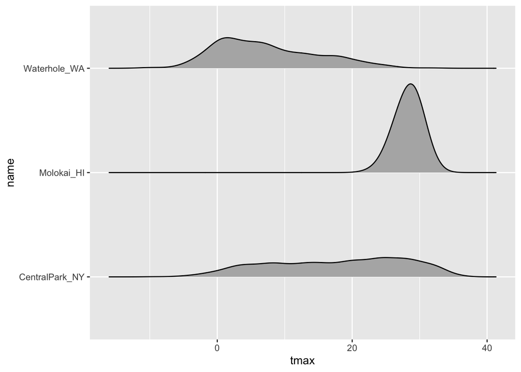

```r
ggplot(weather_df, aes(x = tmax, y = name)) +
  geom_density_ridges(scale = .85)
```

## Saving and embedding plots

DO NOT use built in export function.

Can use ggsave.

Use ggsave() by explicitly creating the figure and exporting; ggsave will guess the file type you prefer and has options for specifying features of the plot. In this setting, it’s often helpful to save the ggplot object explicitly and then export it (using relative paths!).

```r
ggp_weather =
  ggplot(weather_df, aes(x = tmin, y = tmax)) +
  geom_point(aes(color = name), alpha = .5)

ggsave("ggp_weather.pdf", ggp_weather, width = 8, height = 5)
```

First is the size of the figure created by R, which is controlled using two of the three chunk options fig.width, fig.height, and fig.asp. I prefer a common width and plots that are a little wider than they are tall, so I set options to fig.width = 6 and fig.asp = .6. Second is the size of the figure inserted into your document, which is controlled using out.width or out.height. I like to have a little padding around the sides of my figures, so I set out.width = “90%”. I do all this by including the following in a code snippet at the outset of my R Markdown documents.

```r
ggp_weather =
  ggplot(weather_df, aes(x = tmin, y = tmax)) +
  geom_point(aes(color = name), alpha = .5)

ggsave("ggp_weather.pdf", ggp_weather, width = 8, height = 5)
knitr::opts_chunk$set(
  fig.width = 6,
  fig.asp = .6,
  out.width = "90%"
)
```